# VegAreaModels

Matt Webster

2026-07-28

The purpose of this RMarkdown is to implement hierarchical generalized linear mixed effects models for VegArea ~ damPresence, & VegArea ~ damDensity (with and without geomorphic covariates).

4 models total.

```
WAIC indicates that all four models perform comparably well. Given this, I only include code and results for m4, which models the effect of dam density on vegetation area, conditional on geomorphic covariates.
```

**HGLMM**

```
This analysis explores late August vegetation area in relation to beaver dam presence,
& density.

2 models for dam presence (1 without geomorphic covariates; 1 with geomorphic covariates)
2 models for dam density (...^^^...)

All 4 models presented herein are constructed in a hierarchical generalized linear mixed
effects model framework. Stream, year, and sample clusterID are included as random intercepts
for baseline vegetation area. Random slopes were removed from this analysis, due to lack of
group-level variation to support model complexity. See "Ch1_Model_Data_Setup.Rmd". For
the same reason, (lack of variation), sampleEvent was removed as a random effect - no
notable difference in VA among sampleEvents.

Models herein:

  - VA ~ damPresence (no geom.covar.)
  - VA ~ damPresence (geom.covar.)
  - VA ~ damDensity (no geom.covar.)
  - VA ~ damDensity (geom.covar.)

Model structure is simplified from part 2 from the surface water hurdle models. Model
should be structurally parallel with NDVI model.

Uses log(VegArea) for for 6 watersheds, & 3 years.
```

**Final Data:**

```
NOTE: This ONLY uses data from 08/15-08/31. This is to avoid issues with pseudo-replication after the omission of random effects for sample event.

Modeling reflects late August effect of beaver dams on vegetation area. Riparian vegetation = mesic resource that is critical for grouse recruitment.
```

```
## 'data.frame':    676 obs. of  26 variables:
##  $ X               : int  2 6 10 14 18 22 26 30 34 38 ...
##  $ clusterID_seq   : int  1 1 3 3 4 4 5 5 6 6 ...
##  $ window_type     : chr  "dammed" "undammed" "dammed" "undammed" ...
##  $ watershed       : chr  "WC" "WC" "WC" "WC" ...
##  $ year            : int  2019 2019 2019 2019 2019 2019 2019 2019 2019 2019 ...
##  $ catchment_km2   : num  1394 1391 1383 1383 1364 ...
##  $ TO              : num  34.2 35.7 33.2 33.1 45.6 ...
##  $ Nhat            : num  1.13 0 1.13 0 1.13 ...
##  $ t               : int  6 6 6 6 6 6 6 6 6 6 ...
##  $ surveyPeriod    : int  196 196 196 196 196 196 196 196 196 196 ...
##  $ SWA             : num  0 66.7 133.2 332.6 1732.6 ...
##  $ VA              : num  17732 15430 14613 14859 10717 ...
##  $ NDVI            : num  0.359 0.37 0.39 0.347 0.381 ...
##  $ riparian_area_m2: num  2678 2766 2551 2523 3883 ...
##  $ dam_km          : num  4.53 0 4.51 0 4.52 ...
##  $ clusterID_unique: chr  "2019.WC.1" "2019.WC.1" "2019.WC.3" "2019.WC.3" ...
##  $ clusterID_num   : int  16 16 34 34 43 43 52 52 61 61 ...
##  $ stream          : int  6 6 6 6 6 6 6 6 6 6 ...
##  $ sampleEvent     : int  2 2 2 2 2 2 2 2 2 2 ...
##  $ year_id         : int  1 1 1 1 1 1 1 1 1 1 ...
##  $ damPresence     : int  1 0 1 0 1 0 1 0 1 0 ...
##  $ sampleEvent_new : int  2 2 2 2 2 2 2 2 2 2 ...
##  $ logSWA          : num  0 4.21 4.9 5.81 7.46 ...
##  $ y               : int  0 1 1 1 1 1 1 1 1 1 ...
##  $ y_veg           : int  1 1 1 1 1 1 1 1 1 1 ...
##  $ dam_km_std      : num  0.499 -0.94 0.495 -0.94 0.498 ...
```

```
Right skew of vegetation area data warrants log-transformation prior to HGLMM.

Because vegetation is almost always present in our sample reaches, a
hurdle model is not necessary here -- no need to model the presence/absence
process if it's almost always present.
```

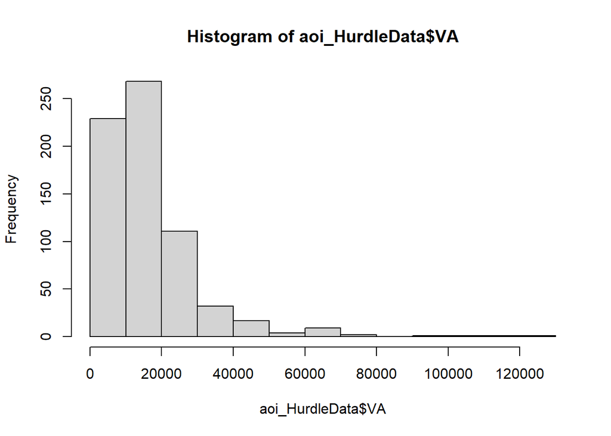

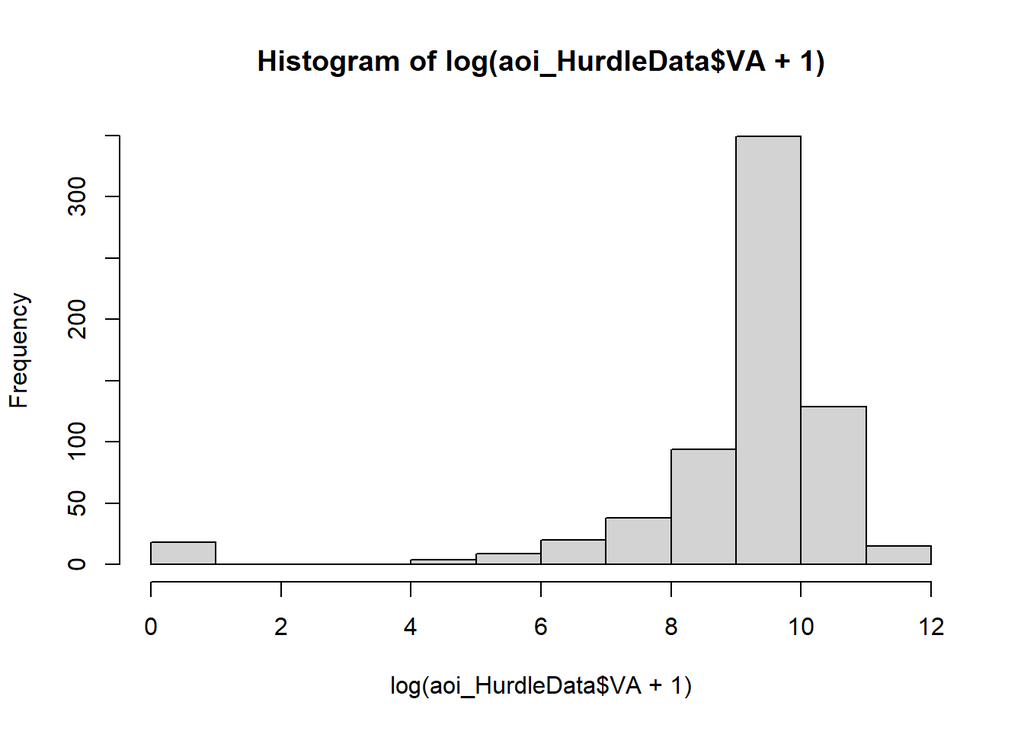

For vegetation models, data of interest include:

```
 - y_vegA: log-transformed vegetation area log(VegArea[i]+1); response variable

- stream: index for random intercept on VegArea

- year: index for random intercept on VegArea

- clusterID_seq: index for random intercept on VegArea; represents sample pairing

- damPres: dam presence (0,1); fixed effect on VegArea

- damDen: dams/km; z-standardized ("...$dam_km_std"); fixed effect on VegArea

Only used in models 2 and 4:

- incis: channel incision: 1-(TO/90) (inverse of topographic openness); z-standardized; fixed effect on
VegArea

- RIPA: riparian area (m^2); z-standardized; fixed effect on VegArea

- UDA: upstream drainage area (km ^2); z-standardized; fixed effect on VegArea
```

**Overall Takeaways**

[output not shown]

## Vegetation Area ~ Dam Presence

**Model 1: VegArea ~ DamPresence**

Effect of damPresence without geomorphic covariates

```
sink("HGLMM_m1_Veg_damPresence.jags")

cat("
model{
  # NEED priors and hyperpriors first so that downstream nodes can be estimated

  ##########################################################################

  # HYPERPRIORS FOR VEG AMOUNT (1/2 Normal on SDs):

  sigma              ~ dnorm(0,1) T(0,)
  tau                <- pow(sigma, -2)

  sigma_eta_stream   ~ dnorm(0, 1) T(0,)
  tau_eta_stream     <- pow(sigma_eta_stream, -2)

  sigma_eta_year    ~ dnorm(0, 1) T(0,)
  tau_eta_year      <- pow(sigma_eta_year, -2)

  sigma_eta_cluster  ~ dnorm(0, 1) T(0,)
  tau_eta_cluster    <- pow(sigma_eta_cluster, -2)

  ##########################################################################
  # FIXED EFFECT PRIORS:

  alpha ~ dnorm(9.07, 0.04)   # within 5SD of empirical mean
  beta_damPres ~ dnorm(0,0.04)

  ##########################################################################

  # RANDOM EFFECT PRIORS FOR VEG AREA:

  for(j in 1:n_stream){
    eta_stream[j]  ~ dnorm(0, tau_eta_stream)
  }

  for(yr in 1:n_year){
    eta_year[yr] ~ dnorm(0, tau_eta_year)
  }

```

[output cut: 16 more lines]

```
                + eta_year[year[i]]
                + eta_cluster[cluster[i]]

  ##########################################################################

  # Derived parameter for WAIC computation:

  loglik[i] <- logdensity.norm(y[i], mu[i], tau)

  }

}
", fill = TRUE)

sink()
```

```
## [1] "2026-08-12 12:33:03 MDT"
```

```
##
## Processing function input.......
##
## Done.
##
## Beginning parallel processing using 3 cores. Console output will be suppressed.
##
## Parallel processing completed.
##
## Calculating statistics.......
##
## Done.
```

```
## [1] "2026-08-12 12:34:18 MDT"
```

**Model 2: VegArea ~ DamPresence + geom.covar.**

Effect of damPresence WITH geomorphic covariates

```
sink("HGLMM_m2_Veg_damPresence.jags")

cat("
model{
  # NEED priors and hyperpriors first so that downstream nodes can be estimated

  ##########################################################################

  # HYPERPRIORS FOR VEG AMOUNT (1/2 Normal on SDs):

  sigma              ~ dnorm(0,1) T(0,)
  tau                <- pow(sigma, -2)

  sigma_eta_stream   ~ dnorm(0, 1) T(0,)
  tau_eta_stream     <- pow(sigma_eta_stream, -2)

  sigma_eta_year   ~ dnorm(0, 1) T(0,)
  tau_eta_year     <- pow(sigma_eta_year, -2)

  sigma_eta_cluster  ~ dnorm(0, 1) T(0,)
  tau_eta_cluster    <- pow(sigma_eta_cluster, -2)

  ##########################################################################
  # FIXED EFFECT PRIORS:

  alpha ~ dnorm(9.07,0.04)  # anchored within 5 SD of empirical mean
  beta_damPres ~ dnorm(0,0.04)
  beta_incis ~ dnorm(0,0.04)
  beta_RIPA ~ dnorm(0,0.04)
  beta_UDA ~ dnorm(0,0.04)

  ##########################################################################

  # RANDOM EFFECT PRIORS FOR SW AMOUNT:

  for(j in 1:n_stream){
    eta_stream[j]  ~ dnorm(0, tau_eta_stream)
  }

  for(yr in 1:n_year){
    eta_year[yr] ~ dnorm(0, tau_eta_year)
  }

  for(c in 1:n_cluster){
    eta_cluster[c] ~ dnorm(0, tau_eta_cluster)
  }

  ##########################################################################

  # MAIN LOOP: PRESENCE, DETECTION, AMOUNT

  for(i in 1:N){

    # Amount:
    y[i] ~ dnorm(mu[i], tau)

    mu[i] <- alpha
                + beta_damPres * damPres[i]
                + beta_incis * incis[i]
                + beta_RIPA * RIPA[i]
                + beta_UDA * UDA[i]
                + eta_stream[stream[i]]
                + eta_year[year[i]]
                + eta_cluster[cluster[i]]

  ##########################################################################

  # Derived parameter for WAIC computation:

  loglik[i] <- logdensity.norm(y[i], mu[i], tau)
  }

}
", fill = TRUE)

sink()
```

```
## [1] "2026-08-12 12:34:27 MDT"
```

```
##
## Processing function input.......
##
## Done.
##
## Beginning parallel processing using 3 cores. Console output will be suppressed.
##
## Parallel processing completed.
##
## Calculating statistics.......
##
## Done.
```

```
## [1] "2026-08-12 12:35:53 MDT"
```

## VegArea ~ Dam Density

**Hurdle HGLMM**

**MODEL 3: VegArea ~ damDensity (no Geom.Covar.)**

```
sink("HGLMM_m3_Veg_damDensity.jags")

cat("
model{
  # NEED priors and hyperpriors first so that downstream nodes can be estimated
  ##########################################################################
  # HYPERPRIORS FOR SW AMOUNT (1/2 Normal on SDs):

  sigma              ~ dnorm(0,1) T(0,)
  tau                <- pow(sigma, -2)

  sigma_eta_stream   ~ dnorm(0, 1) T(0,)
  tau_eta_stream     <- pow(sigma_eta_stream, -2)

  sigma_eta_year   ~ dnorm(0, 1) T(0,)
  tau_eta_year     <- pow(sigma_eta_year, -2)

  sigma_eta_cluster  ~ dnorm(0, 1) T(0,)
  tau_eta_cluster    <- pow(sigma_eta_cluster, -2)

  ##########################################################################
  # FIXED EFFECT PRIORS:

  alpha ~ dnorm(9.07,0.04)  # within 5 SD of empirical mean log(VA+1)
  beta_damDen ~ dnorm(0,0.04)

  ##########################################################################
  # RANDOM EFFECT PRIORS FOR Veg AMOUNT:

  for(j in 1:n_stream){
    eta_stream[j]  ~ dnorm(0, tau_eta_stream)
  }

  for(yr in 1:n_year){
    eta_year[yr] ~ dnorm(0, tau_eta_year)
  }

  for(c in 1:n_cluster){
    eta_cluster[c] ~ dnorm(0, tau_eta_cluster)
  }

  ##########################################################################
  # MAIN LOOP: PRESENCE, DETECTION, AMOUNT

  for(i in 1:N){

    y[i] ~ dnorm(mu[i], tau)

    mu[i] <- alpha
                + beta_damDen * damDen[i]
                + eta_stream[stream[i]]
                + eta_year[year[i]]
                + eta_cluster[cluster[i]]

  ##########################################################################

  # Derived parameter for WAIC computation:

  loglik[i] <- logdensity.norm(y[i], mu[i], tau)
  }
}
", fill = TRUE)

sink()
```

```
## [1] "2026-08-12 12:36:15 MDT"
```

```
##
## Processing function input.......
##
## Done.
##
## Beginning parallel processing using 3 cores. Console output will be suppressed.
##
## Parallel processing completed.
##
## Calculating statistics.......
##
## Done.
```

```
## [1] "2026-08-12 12:37:30 MDT"
```

**MODEL 4: SW ~ damDensity + Geom.Covar.**

```
sink("HGLMM_m4_Veg_damDensity.jags")

cat("
model{
  # NEED priors and hyperpriors first so that downstream nodes can be estimated
  ##########################################################################
  # HYPERPRIORS FOR Vegetation Area (1/2 Normal on SDs):

  sigma              ~ dnorm(0,1) T(0,)
  tau                <- pow(sigma, -2)

  sigma_eta_stream   ~ dnorm(0, 1) T(0,)
  tau_eta_stream     <- pow(sigma_eta_stream, -2)

  sigma_eta_year    ~ dnorm(0, 1) T(0,)
  tau_eta_year      <- pow(sigma_eta_year, -2)

  sigma_eta_cluster  ~ dnorm(0, 1) T(0,)
  tau_eta_cluster    <- pow(sigma_eta_cluster, -2)

  ##########################################################################
  # FIXED EFFECT PRIORS:

  # Amount:
  alpha ~ dnorm(9.07,0.04)  # within 5 SD of empirical mean vegArea
  beta_damDen ~ dnorm(0,0.04)
  beta_incis ~ dnorm(0,0.04)
  beta_RIPA ~ dnorm(0,0.04)
  beta_UDA ~ dnorm(0,0.04)

  ##########################################################################
  # RANDOM EFFECT PRIORS FOR VegArea:

  for(j in 1:n_stream){
    eta_stream[j]  ~ dnorm(0, tau_eta_stream)
  }

  for(yr in 1:n_year){
    eta_year[yr] ~ dnorm(0, tau_eta_year)
  }

  for(c in 1:n_cluster){
    eta_cluster[c] ~ dnorm(0, tau_eta_cluster)
  }

  ##########################################################################
  ##########################################################################
  # MAIN LOOP: PRESENCE, DETECTION, AMOUNT

  for(i in 1:N){

    y[i] ~ dnorm(mu[i], tau)

    mu[i] <- alpha
                + beta_damDen * damDen[i]
                + beta_incis * incis[i]
                + beta_RIPA * RIPA[i]
                + beta_UDA * UDA[i]
                + eta_stream[stream[i]]
                + eta_year[year[i]]
                + eta_cluster[cluster[i]]

  ##########################################################################

  # Derived parameter for WAIC computation:

  loglik[i] <- logdensity.norm(y[i], mu[i], tau)
  }

}
", fill = TRUE)

sink()
```

```
## [1] "2026-08-12 12:37:37 MDT"
```

```
##
## Processing function input.......
##
## Done.
##
## Beginning parallel processing using 3 cores. Console output will be suppressed.
##
## Parallel processing completed.
##
## Calculating statistics.......
##
## Done.
```

```
## [1] "2026-08-12 12:39:07 MDT"
```

## DIAGNOSTICS:

**Assess “Chain health” Rhat + ESS:**

```
## Potential scale reduction factors:
##
##             Point est. Upper C.I.
## alpha                1          1
## beta_damDen          1          1
## beta_incis           1          1
## beta_RIPA            1          1
## beta_UDA             1          1
## sigma                1          1
```

```
##       alpha beta_damDen  beta_incis   beta_RIPA    beta_UDA       sigma
##    44625.76    45000.00    45000.00    44958.01    42760.38    34207.30
```

[output not shown]

**Check traceplots** for critical parameters:

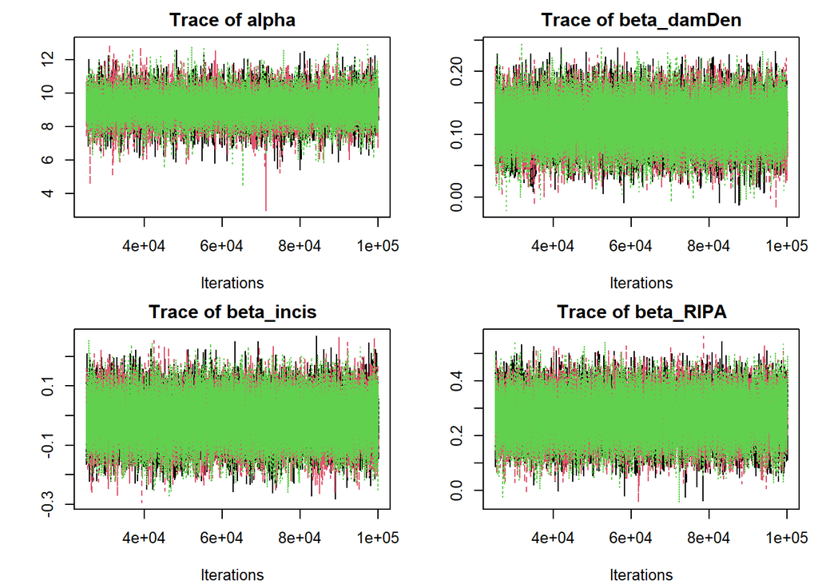

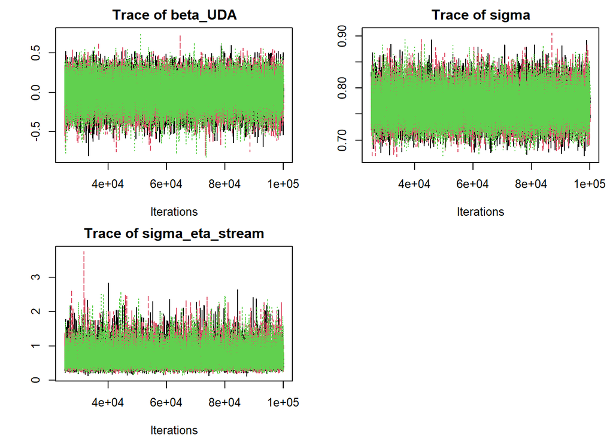

```
Traceplots all look good.
```

**Predicted log(VA) vs observed log(VA)**

Goal is 1:1 (ish)

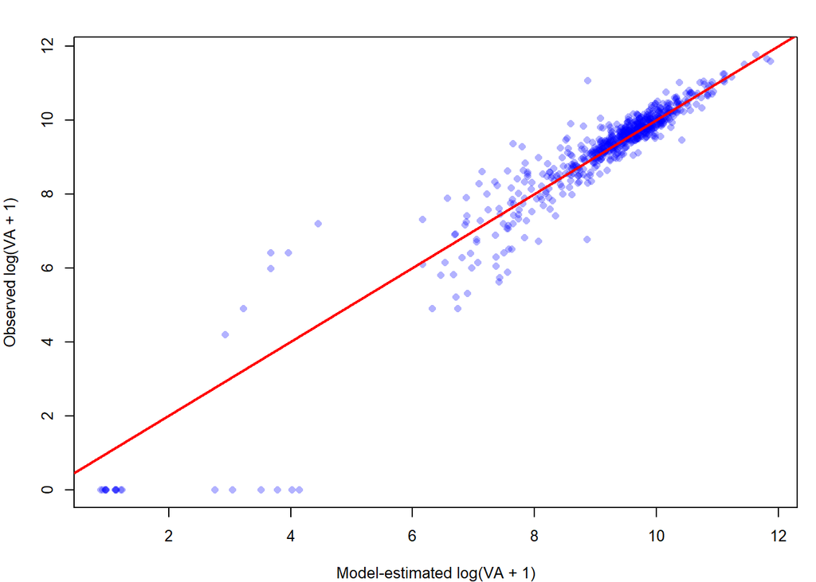

Slope:

```
## m4_mu_veg_post
##       1.097647
```

```
Near 1 = good
```

**Random effects shrinkage:**

Goal is centered around 0(ish)

1. eta_year; random effect of year log(VA+1) intercept
2. eta_stream; random effect of stream on log(VA+1) intercept

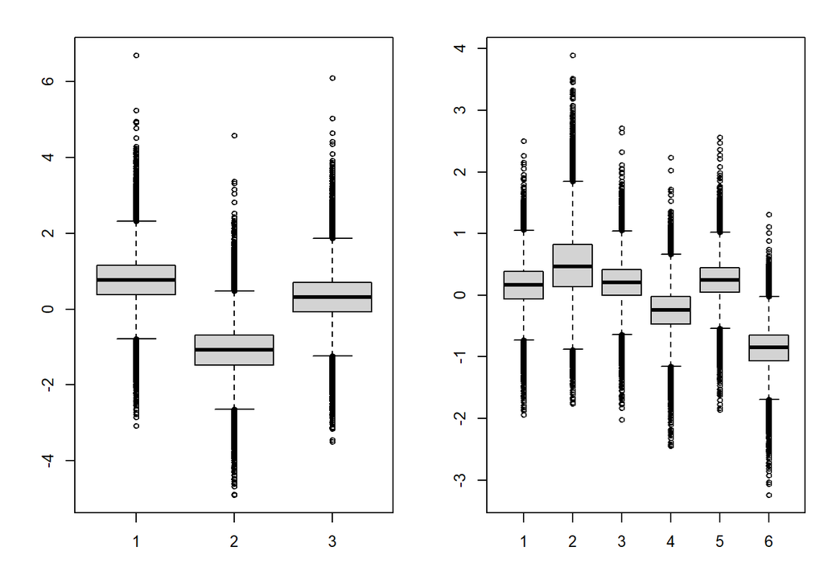

**Prior-posterior overlap:**

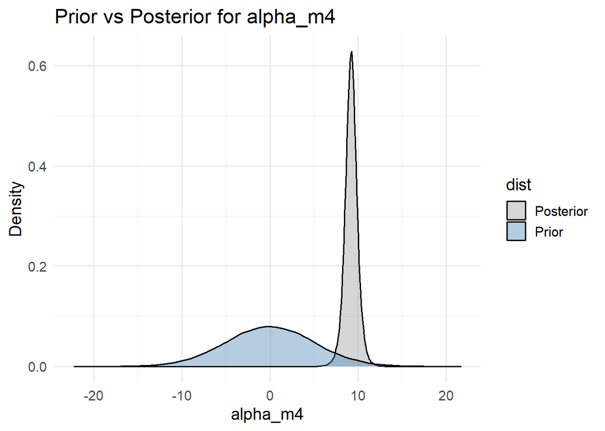

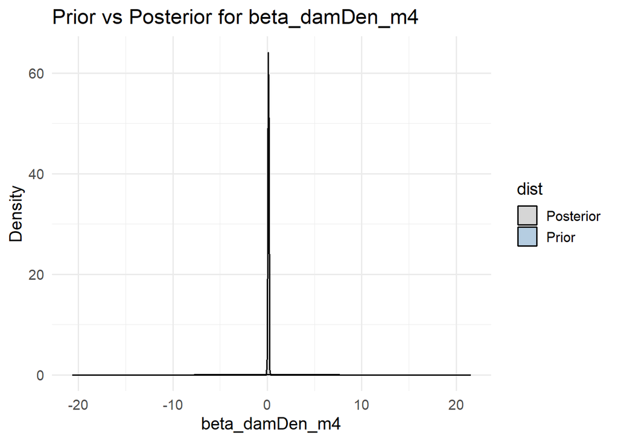

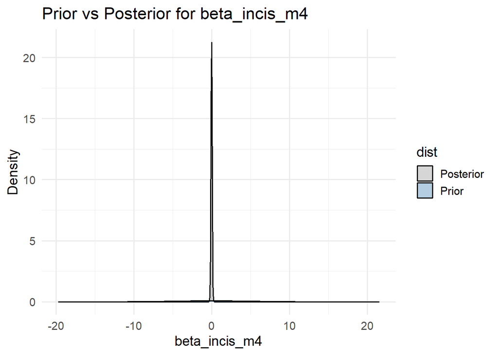

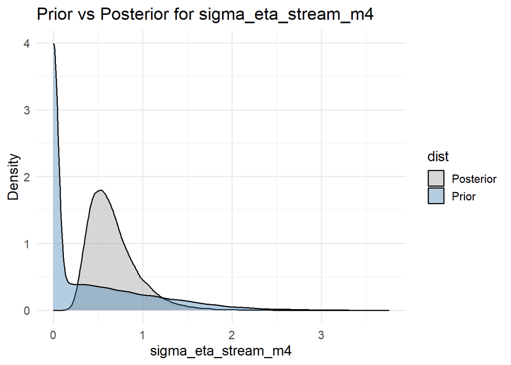

```
PPOs look good pretty good.
```

**Posterior Estimates**

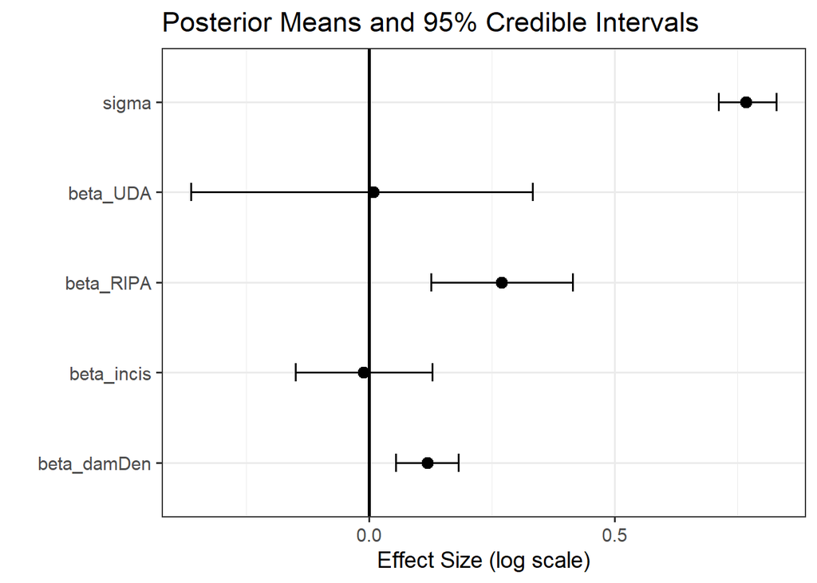

**Effect of 1 SD increase in dam density on vegetation area:**

```
##     Min.  1st Qu.   Median     Mean  3rd Qu.     Max.
## -0.02131  0.09663  0.11857  0.11857  0.14054  0.24419
```

```
## [1] 1.125885
```

```
## [1] "VA change with 1 SD increase in dam density"
```

```
## [1] 1340.809
```

[output not shown]

**Estimated effects of geomorphic covariates**

**Effect of 1 SD increase in incision on vegetation area:**

```
##     Min.  1st Qu.   Median     Mean  3rd Qu.     Max.
## -0.29275 -0.05800 -0.01036 -0.01037  0.03757  0.26915
```

```
## [1] 0.9896873
```

```
## [1] "VA change with 1 SD increase in incision"
```

```
## [1] -99.35252
```

```
A 1 SD increase in incision (~0.1) is associated with a ~1% decrease in vegetation area.
For a typical stream at mean covariate conditions, this corresponds to a decrease in ~ 99 m^2.

<Weak negative effect, heavily overlapping 0.>
```

**Effect of 1 SD increase in riparian area on vegetation area:**

```
##    Min. 1st Qu.  Median    Mean 3rd Qu.    Max.
## -0.0447  0.2214  0.2705  0.2707  0.3199  0.5641
```

```
## [1] 1.310849
```

```
## [1] "VA change with 1 SD increase in riparian area"
```

```
## [1] 3628.804
```

```
A 1 SD increase in RIPA (11000 m^2) is associated with a ~ 31% increase in vegetation area.
This corresponds with an increase of ~3600 m^2 (for typical stream under mean conditions).
```

**Effect of 1 SD increase in Upstream Drainage Area on SW amount:**

```
##      Min.   1st Qu.    Median      Mean   3rd Qu.      Max.
## -0.828882 -0.102483  0.015569  0.008288  0.127925  0.757839
```

```
## [1] 1.008322
```

```
## [1] "VA change with 1 SD increase in drainage area"
```

```
## [1] 80.20046
```

```
A 1 SD increase in Upstream Drainage Area (UDA) (~1300km^2) is associated with a 0.8% increase in
vegetation area. This corresponds to an increase of ~ 80 m^2 in VA (m^2) for a
"typical" stream at mean covariate conditions.
```

**Partial dependence plots**

Constrain PDP to empirical ranges for SWA and target covariates

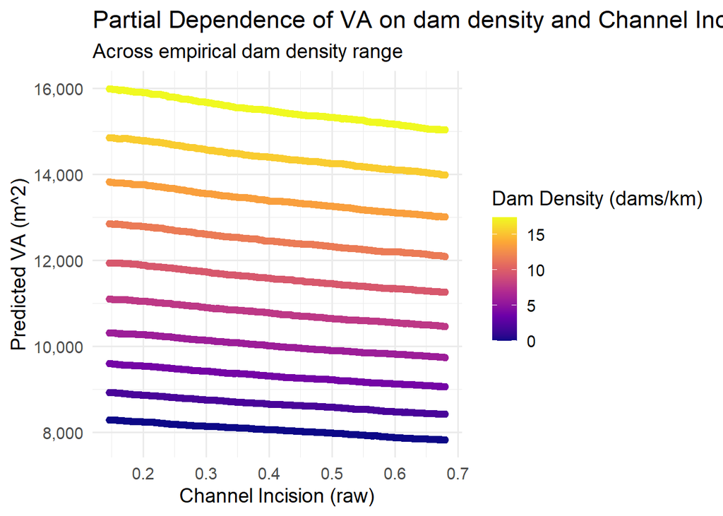

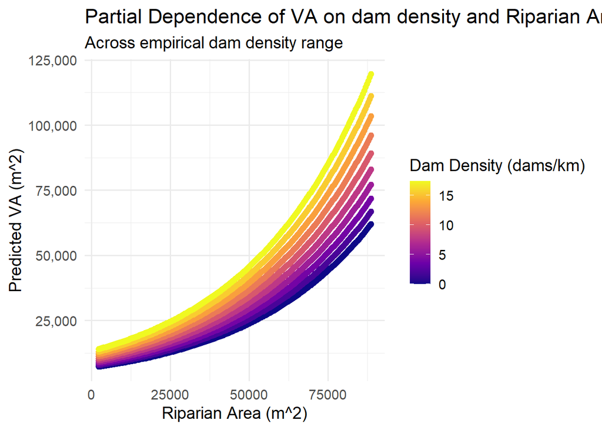

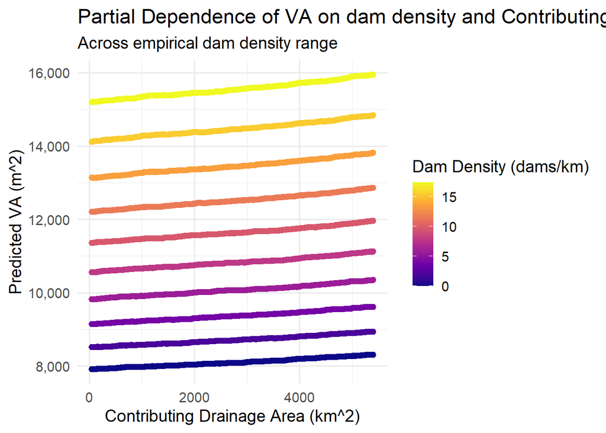

**Change in VA across damDensity by stream and sampleEvent**

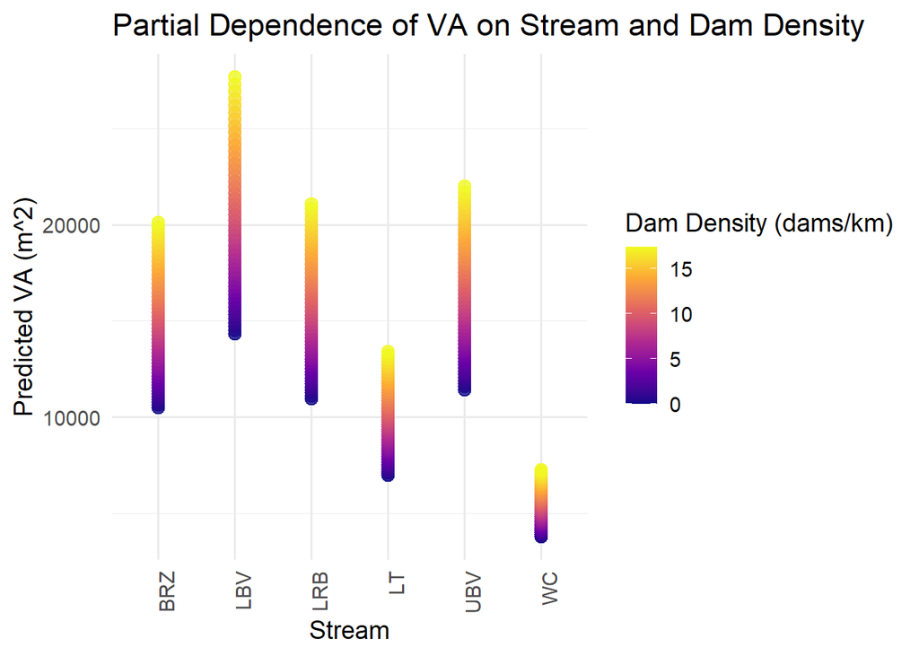

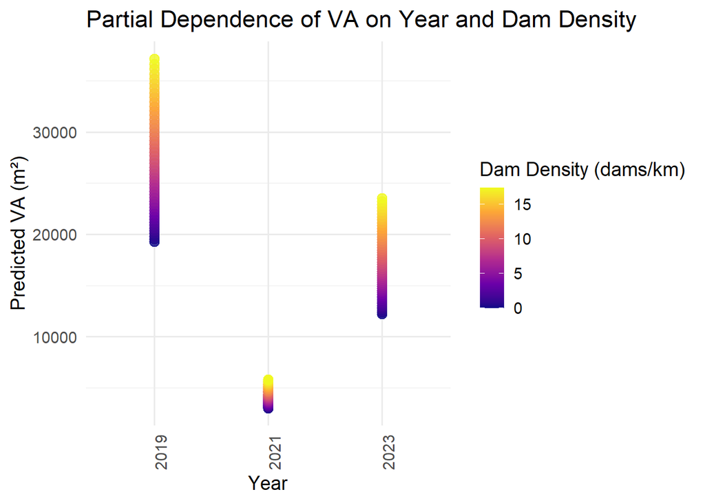

**Model Comparison**

```
## # A tibble: 4 × 2
##   model  WAIC
##   <chr> <dbl>
## 1 m2    1858.
## 2 m4    1859.
## 3 m3    1859.
## 4 m1    1861.
```

```
According to WAIC comparison, all 4 models perform comparably. M4 provides the
most complete story, as it covers dam presence/absence via the damDensity gradient
as well as geomorphic covariates.

Recommendation: use M4 (VA ~ damDensity + geomorphicCovariates) for manuscript
results
```